# Project linear model

Author

Nisha Josh

For this stage of the project we’ll fit a linear model.

```r
library(tidyverse)
```

If your data is not suitable for regression, then please find a data set from https://www.openintro.org/data/

## 1 Variables

*Load the data and find a numerical column that you can use as a response (y value) and another column that you can use as a predictor (x value). Show 6 rows of the data with these two columns.*

```r
 lego <- read_csv("https://www.openintro.org/data/csv/lego_population.csv")
```

```r
  lego |>
    select(price, pieces) |>
    slice_sample(n=6)
```

```
# A tibble: 6 × 2
  price pieces
  <dbl>  <dbl>
1  70.0    882
2  70.0    574
3  50.0    425
4  NA       61
5  NA       72
6  NA       NA
```

*Describe why this prediction problem is interesting to you or someone else. Who would care about these predicted values, and why?*

ANS: I chose number of pieces as a predictor to predict price of the lego sets from the no of pieces in it. The predicted values would help me analyze how much they charge on an average for each piece.

## 2 Scatter plot

*Make a scatter plot with the response value on the y axis and the predictor value on the x axis. Use `geom_smooth(method = "lm")` to add the least squares line. Does a linear model seem appropriate?*

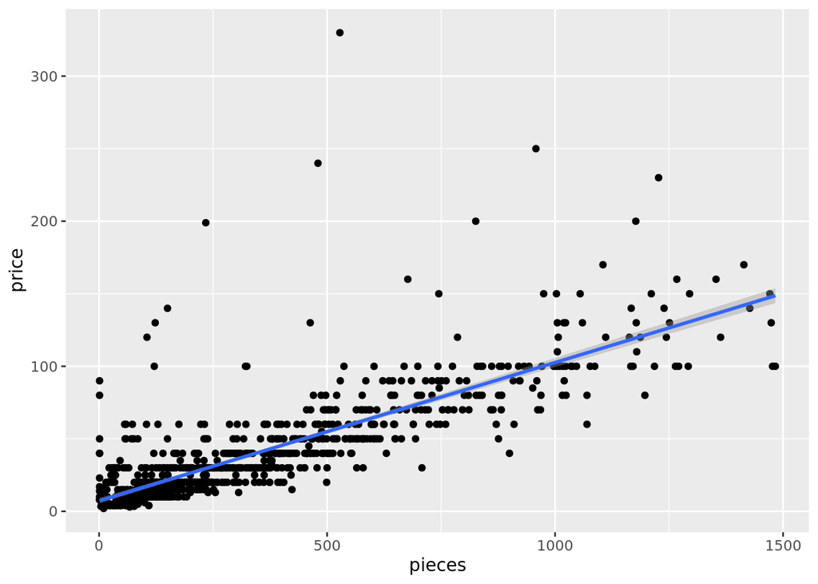

```r
  lego |>
    filter(pieces<1500) |>
    ggplot(aes(x = pieces, y = price)) +
      geom_point() +
        geom_smooth(method = 'lm')
```

ANS: Yes, the linear model seems appropriate for the response value on the y axis and the predictor value on the x axis.

## 3 Model

*Fit a linear model, save it in the variable `mod1` and print it.*

```r
   mod1 <- lm(price ~ pieces, data = lego)
   print(mod1)
```

```
Call:
lm(formula = price ~ pieces, data = lego)

Coefficients:
(Intercept)       pieces
   10.85976      0.08219
```

*Write the mathematical model it represents, using the fitted coefficients to replace the ? symbols in the equation.*

$$Y_i = 10.86 + 0.082X_i + e_i$$
ANS: $Y_i$ is the price $X_i$ is the number of pieces.

## 4 Predict

Prediction of the price for a lego set with 100 pieces.

$$Y_i = 10.86 + 0.082(100)$$

```r
10.86 + 0.082*100
```

```
[1] 19.06
```

ANS: The predicted price is $19.06.

Use the model to predict the price

```r
predict(mod1, data.frame(pieces = 100))
```

```
       1
19.07832
```

5. Extra Question

How much would it cost to purchase a LEGO set that contains at least 50 unique, non-repeating pieces?

```r
lego |>
    select(price, unique_pieces) |>
    slice_sample(n=6)
```

```
# A tibble: 6 × 2
  price unique_pieces
  <dbl>         <dbl>
1  3.99            25
2 20.0            116
3 60.0            242
4 50.0            160
5 NA               22
6 NA               NA
```

```r
   mod2 <- lm(price ~ unique_pieces, data = lego)
   print(mod2)
```

```
Call:
lm(formula = price ~ unique_pieces, data = lego)

Coefficients:
  (Intercept)  unique_pieces
      -3.6503         0.3834
```

ANS: So, according to the model, the predicted price for a LEGO set with 50 unique pieces is approximately $15.52.